# Peer Assessment 1

## Activity Monitoring Data Analysis

The activity monitoring data is loaded as an R dataset. The dataset includes the number of steps, date, and interval for each activity.

```r
data <- read.csv("activity.csv")
originaldata <- data
drop <- is.na(data$steps)
data <- data[!drop,]
data$date <- as.Date(data$date)
originaldata$date<-as.Date(originaldata$date)
```

1. Calculate the total number of steps taken per day

```r
library(dplyr)
data<-group_by(data,date)
numsteps <- summarise(data,totalsteps = sum(steps))
```

2. Create a histogram of the total number of steps per activity.

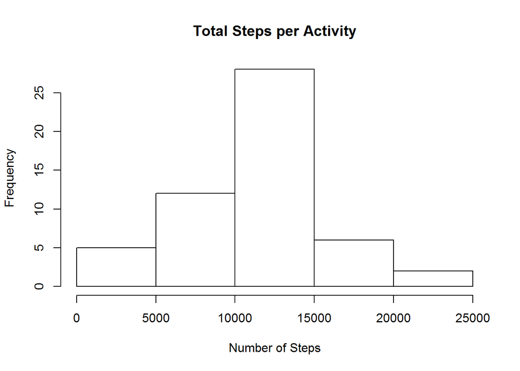

```r
hist(numsteps$totalsteps,main="Total Steps per Activity",xlab ="Number of Steps")
```

```r
summarysteps <- summarise(data,meansteps = mean(steps),mediansteps=median(steps))
as.data.frame(summarysteps)
```

```
##          date  meansteps mediansteps
## 1  2012-10-02  0.4375000           0
## 2  2012-10-03 39.4166667           0
## 3  2012-10-04 42.0694444           0
## 4  2012-10-05 46.1597222           0
## 5  2012-10-06 53.5416667           0
## 6  2012-10-07 38.2465278           0
## 7  2012-10-09 44.4826389           0
## 8  2012-10-10 34.3750000           0
## 9  2012-10-11 35.7777778           0
## 10 2012-10-12 60.3541667           0
## 11 2012-10-13 43.1458333           0
## 12 2012-10-14 52.4236111           0
## 13 2012-10-15 35.2048611           0
## 14 2012-10-16 52.3750000           0
```

[output cut: 39 more lines]

The average daily activity pattern of the 5-minute interval and the steps are determined and plotted as a time series.

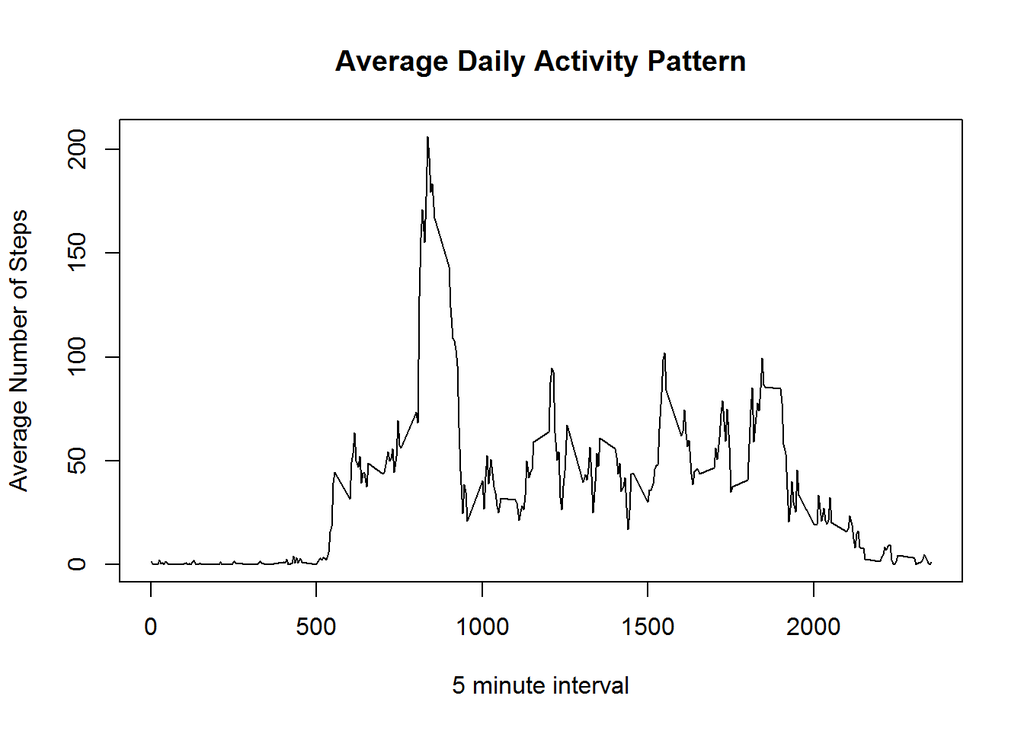

```r
data<-ungroup(data)
data<-group_by(data,interval)
intercalc <- summarise(data,meansteps = mean(steps))
plot(intercalc$interval,intercalc$meansteps,type="l",main="Average Daily Activity Pattern",xlab="5 minute interval",ylab="Average Number of Steps")
```

The maximum average number of steps is found on the 5 minute interval.

```r
intercalc2 <- arrange(intercalc,desc(meansteps))
intercalc2 <- head(intercalc2,1)
max<-intercalc2$interval
```

The interval with the maximum number of steps is 835.

The total number of missing data in the dataset is determined.

```r
numna <- sum(drop)
```

The total number of missing data in the dataset is 2304.

For days with missing data, the missing data is replaced with the average number of steps at that interval taken over the entire number of days in the sample set.

```r
newdata <- originaldata
mergedata<- merge(newdata,intercalc,by="interval",all.x=T)
drop <- is.na(mergedata$steps)
mergedata <- mutate(mergedata[drop,],steps=meansteps)
mergedata <- group_by(mergedata,date)
alldata <- summarise(mergedata,totalsteps=sum(steps),mean2=mean(steps),median=median(steps))
```